# Can you predict stock price movements using neural networks

## a project by Alexander Michalik, Lukas Schneider, Sebastian Bielfeldt and Jesse Jones

- Objective
- Data Preparation
  - One-Hot Encoding
- Evaluation Functions
- Neural Network Models
  - Convolutional Neural Network
    - Convolutional Neural Network with OHE Branch Input
  - Fully Connected Neural Network
  - Recurrent Neural Network with LSTM
    - Recurrent Neural Network with LSTM and OHE Branch Input
  - Recurrent Neural Network with GRU
    - Recurrent Neural Network with GRU and OHE Branch Input

## Objective

## Data

- adjusted close values
- N = 20 stocks
- $t_{min} = 2007 \, ,\quad t_{max} = 2017$

```python
begin = "2007-01-01"
finish = "2017-01-01"
N=20

#Schema für Datenverarbeitung

#data_loader(begin, finish, 'returns.csv')
returns = get_returns('returns.csv', N)
delete_nans('returns.csv', 'returns.csv')
data_head('returns.csv', N)
```

```
Number of NaNs: 0
shape Dataframe: (2518, 20)
```

| Date | MMM | ABT | ABBV | ABMD | ACN | ATVI | ADBE | AMD | AAP | AES | AMG | AFL | A | APD | AKAM | ALK | ALB | ARE | ALXN | ALGN |
| --- | --- | --- | --- | --- | --- | --- | --- | --- | --- | --- | --- | --- | --- | --- | --- | --- | --- | --- | --- | --- |
| 2007-01-03 | 0.000000 | 0.000000 | 0.0 | 0.000000 | 0.000000 | 0.000000 | 0.000000 | 0.000000 | 0.000000 | 0.000000 | 0.000000 | 0.000000 | 0.000000 | 0.000000 | 0.000000 | 0.000000 | 0.000000 | 0.000000 | 0.000000 | 0.000000 |
| 2007-01-04 | -0.003961 | 0.018991 | 0.0 | 0.021352 | 0.022540 | 0.008158 | 0.022545 | 0.013832 | 0.006464 | 0.000456 | -0.010861 | -0.011027 | 0.003207 | -0.021972 | 0.023622 | 0.019508 | -0.004584 | -0.001686 | 0.002955 | 0.018727 |
| 2007-01-05 | -0.006799 | 0.000000 | 0.0 | -0.014634 | -0.013979 | -0.005780 | -0.004900 | -0.004043 | -0.022061 | -0.028702 | -0.008021 | 0.001312 | -0.009299 | -0.013934 | -0.002064 | -0.036116 | -0.017446 | -0.019664 | -0.006629 | 0.002941 |
| 2007-01-08 | 0.002195 | 0.003607 | 0.0 | -0.002122 | 0.014449 | -0.000581 | -0.004185 | -0.012177 | 0.003427 | -0.014071 | 0.013187 | 0.000655 | -0.003520 | -0.001298 | -0.003384 | 0.021092 | -0.005114 | -0.009523 | -0.027435 | 0.002933 |
| 2007-01-09 | 0.001160 | 0.008786 | 0.0 | -0.010631 | -0.002419 | -0.000582 | -0.020272 | 0.009245 | 0.008537 | -0.040914 | 0.009690 | 0.003709 | 0.001178 | -0.002166 | -0.006414 | 0.008263 | 0.005854 | 0.024956 | -0.007624 | 0.001462 |

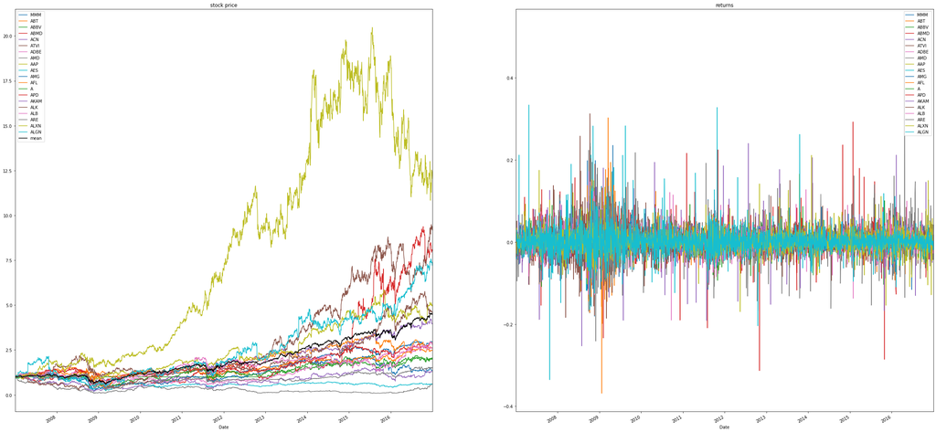

```python
plot_example_returns1('returns.csv', N)
```

```python
def get_data_subsets(df, dur, variant, onehot):
    """
    variant options: month, vola, next_day
    """

    branches_ = pd.read_csv('snp500info.csv', index_col=0)
    branches = branches_.drop(columns = ['Security', 'GICS Sub Industry', 'start at yahoo'])

    companies = list(df)
    data_onehot = branches.loc[branches.index.isin(companies)].iloc[:,0]
    # integer encode
    label_encoder = LabelEncoder()
    integer_encoded = label_encoder.fit_transform(data_onehot)
    # binary encode
    onehot_encoder = OneHotEncoder(sparse=False)
    integer_encoded = integer_encoded.reshape(len(integer_encoded), 1)
    onehot_encoded = onehot_encoder.fit_transform(integer_encoded).T

    df = np.array(df)
    month = 30
    leng = df.shape[0]
    x=[]
    y=[]
    for i in range(leng):
        if dur+i>=leng:
            break
        if onehot:
            x_inp = np.concatenate((onehot_encoded, df[i:dur+i,:]))
        else:
            x_inp = df[i:dur+i,:]

        if variant == 'vola':
            x.append(x_inp)
            y.append(np.abs(df[dur+i,:]))
        else:
            x.append(x_inp)
            if variant == 'month':
                y.append(np.mean(df[dur+i:dur+i+month,:]))
            elif variant == 'next_day':
                y.append(df[dur+i,:])
            else:
                raise NameError("Use correct fun_label")
    return np.array(x),np.array(y)
```

### One Hot Encoding of Branch Information

```python
pd.read_csv('snp500info.csv', index_col=0).head()
branches_ = pd.read_csv('snp500info.csv', index_col=0)
branches = branches_.drop(columns = ['Security', 'GICS Sub Industry', 'start at yahoo'])
branches.head()
```

| Ticker symbol | GICS Sector |
| --- | --- |
| MMM | Industrials |
| ABT | Health Care |
| ABBV | Health Care |
| ACN | Information Technology |
| ATVI | Information Technology |

```python
data = branches.iloc[:,0]
# integer encode
label_encoder = LabelEncoder()
integer_encoded = label_encoder.fit_transform(data)
print(integer_encoded)
# binary encode
onehot_encoder = OneHotEncoder(sparse=False)
integer_encoded = integer_encoded.reshape(len(integer_encoded), 1)
onehot_encoded = onehot_encoder.fit_transform(integer_encoded)
print(onehot_encoded)
```

[output not shown]

## Evaluation Functions

Evaluation Types:

- Sign test
- Predicition vs Result
- Simultaneous Plot over Time
- Top 5 Portfolio Test

### Sign Test

- Compares Signs of Model Prediction and Data
- Absolute Test of Prediction Quality

```python
def directional_goodness(model,x_test,y_test):
    """
    directional goodnes gives the factor of correctly predicted signs of first order derivative of returns to false ones
    oder auch:
    gibt die Anzahl der Beobachtungen an, deren Vorhersage das richtige Vorzeichen hatte (Kurs steigt, Kurs fällt)
    """

    try:
        y_pred = model.predict(x_test)
    except AttributeError:
        y_pred = model(x_test)
    count = 0
    #print(y_new.shape)
    for i in range(len(y_pred)):
        for j in range(len(y_pred[i])):
            p= y_pred[i,j] > 0
            n = y_test[i,j] > 0
            if n==p:
                count +=1
    print('percentage of correctly predicted directions of returns: ' + str(count/len(y_pred)/len(y_pred[0])))
```

### Top 5 Portfolio Test

- Select 5 stocks with highest expected portfolio
- Calculate Mean Return of top 5 stocks
- Compare with Mean Return of all Stocks
- Relative Test of prediction quality

```python
def largest(array, amount):
    return array.argsort()[:,-amount:]


def compare_top(model, x_test, y_test):
    try:
        y_pred = model.predict(x_test)
    except AttributeError:
        y_pred = model(x_test)
    amount = 5
    mean_all = np.mean(y_test)

    top_index = largest(y_pred,amount)
    mean_mach = np.mean(y_test[top_index])
    ret = mean_mach-mean_all
    print('Difference between mean return and return of calculated top 5: ' + str(ret))
    return ret

#compare_top(model, x_test, y_test)
```

### Prediction vs Result

- Scatter Plot Prediction/Result
- Visualize the Data

```python
def internal_goodness(model, x_new, y_new):
    print('compare true to predicted values of internal validation on learned dataset: ')
    y_pred = model.predict(x_new)
    #model.predict nimmt x-werte und gibt die predicteten y-werte zurück
    plt.scatter(y_new, y_pred)
```

### Simultaneous Plot over Time

- Plot both expected Returns and Actual Returns over time
- Visualize the Data

```python
def external_goodness(model, x_new, y_new):
    print('compare true to predicted values of external validation set: ')
    y_pred = model.predict(x_new)
    color =  ["r", "b", "g"]
    for i in range(3):
        plt.plot(y_new[:20,i],c=color[i], label = 'true')
        plt.plot(y_pred[:20,i], c=color[i], linestyle='--', label = 'pred')
    plt.legend()
```

## Models

- moving average
- 1D CNN
- RNN
  - LSTM
  - GRU
- fully connected Network

### Moving average

```python
def mov_avg(x_train):
    print(np.array(x_train).shape)
    return np.sum(x_train, axis = 1)/len(x_train)
```

```
(518, 100, 20)
percentage of correctly predicted directions of returns: 0.5218146718146718
(518, 100, 20)
Difference between mean return and return of calculated top 5: 0.0010474857982434359
(518, 100, 20)
(1900, 100, 20)
(518, 20)
```

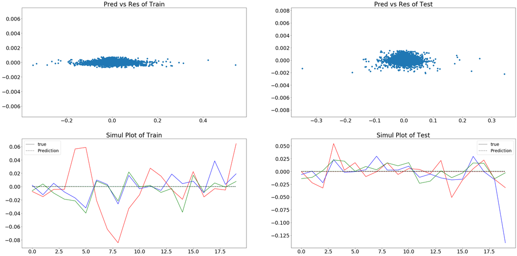

```python
directional_goodness(mov_avg, x_test, y_test)
compare_top(mov_avg, x_test, y_test)
plots(mov_avg, x_test=x_test, x_train=x_train, y_test=y_test, y_train=y_train)
```

### Convolutional Neural Network

```python
def cnn(x_train, y_train, x_test, y_test, inp_shape):
    verbose, epochs, batch_size = 0, 40, 50
    """
    verbose: 0-kein output, 1-ladebalken, 2-epochenzahlen printen
    batch_size: Nicht definieren (https://stackoverflow.com/questions/44747343/keras-input-explanation-input-shape-units-batch-size-dim-etc)
    epochs: Anzahl Iterationen durch das Trainingsset
    """

    N = inp_shape[1]
    #init
    model = models.Sequential()
    model.add(layers.Conv1D(filters=64, kernel_size=3, activation='relu',
                     input_shape=inp_shape))
    model.add(layers.Conv1D(filters=64, kernel_size=3, activation='relu'))
    #Conv1D => 1D Convolution (Schaut nach Mustern)
    #mit filters = Anzahl Weight Functions, kernel_size = Anzahl simultan betrachteter Felder,
    #relu = 0 für value<0 sonst linear

    model.add(layers.Dropout(0.3))
    #Dropout sets randomly chosen values to 0 to prevent overfitting

    model.add(layers.MaxPooling1D(pool_size=2))
    #MaxPooling halbiert array Größe und nimmt größte Werte der Feature-Gewichtungen

    model.add(layers.Flatten())
    #Flatten reduziert dimensionen eines arrays auf niedrigst mögliche Dimension (1xdim) (überschreibt Nullen))

    model.add(layers.Dense(100, activation='relu'))
    model.add(layers.Dense(N, activation='linear'))
    #Klassisches NN hinter Convolutional Layer geschaltet, lernt also im Feature Raum, durch Convolutional Net vorgebenen

    model.compile(loss='mean_squared_error', optimizer='adam', metrics=['mse', 'mae'])
    #mean_squared_error (mse) and mean_absolute_error (mae)

    #fit network
    model.fit(x_train,y_train, epochs=epochs, #batch_size=batch_size,
              verbose=verbose)
    #evaluate model

    #Print error values for classification of goodness
    mse,mse2,mae = model.evaluate(x_test,y_test, batch_size=batch_size, verbose=verbose)
    print(mse)
    print(mse2)
    print(mae)
    return model
```

```python
def main_cnn(input_df, dur, limit, variant):
    """
    input_df    die Input Matrix (duh)
    dur         Zeitfenster
    limit       Grenze für Train Test Split
    variant     prediction of next day, next month average, volatility
    """

    N = input_df.shape[1]
    D = input_df.shape[0]
    train = input_df.iloc[:limit,:]
    test = input_df.iloc[limit-dur:,:]
    x_train,y_train = get_data_subsets(train, dur, variant="next_day", onehot=0)
    x_test,y_test = get_data_subsets(test, dur, variant="next_day", onehot=0)
    inp_shape = (dur,N)

    x_train = x_train[:,x_train.shape[1]-dur:,:]
    x_test = x_test[:,x_test.shape[1]-dur:,:]

    """für Dimensions-tests"""
    print('x-train shape: ' + str(x_train.shape))
    print('y-train shape: ' + str(y_train.shape))
    print('x-test shape: ' + str(x_test.shape))
    print('y-test shape: ' + str(y_test.shape))
    print('test shape: ' + str(test.shape))

    model = cnn(x_train, y_train, x_test, y_test, inp_shape)
    return model,x_train,y_train,x_test,y_test
```

```python
model_cnn,x_train,y_train,x_test,y_test = main_cnn(returns, 100, 2000, variant='next_day')
print(model_cnn.summary())
```

```
x-train shape: (1900, 100, 20)
y-train shape: (1900, 20)
x-test shape: (518, 100, 20)
y-test shape: (518, 20)
test shape: (618, 20)
0.00039471909008258557
0.0003947190416511148
0.012898831628262997
Model: "sequential_1"
_________________________________________________________________
Layer (type)                 Output Shape              Param #
=================================================================
conv1d_1 (Conv1D)            (None, 98, 64)            3904
_________________________________________________________________
conv1d_2 (Conv1D)            (None, 96, 64)            12352
_________________________________________________________________
dropout_1 (Dropout)          (None, 96, 64)            0
_________________________________________________________________
max_pooling1d_1 (MaxPooling1 (None, 48, 64)            0
_________________________________________________________________
flatten_1 (Flatten)          (None, 3072)              0
_________________________________________________________________
dense_1 (Dense)              (None, 100)               307300
_________________________________________________________________
dense_2 (Dense)              (None, 20)                2020
=================================================================
Total params: 325,576
Trainable params: 325,576
Non-trainable params: 0
_________________________________________________________________
None
```

```
percentage of correctly predicted directions of returns: 0.5254826254826255
Difference between mean return and return of calculated top 5: -0.0014379054174214442
(518, 20)
```

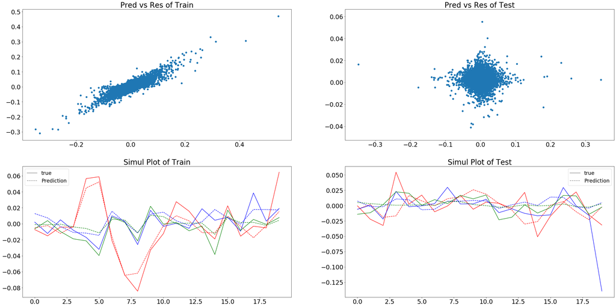

```python
directional_goodness(model_cnn, x_test, y_test)
compare_top(model_cnn, x_test, y_test)
plots(model_cnn, x_test=x_test, x_train=x_train, y_test=y_test, y_train=y_train)
```

Expectations:

- CNN learns patterns in stock market changes, if there are any recognisable patterns
- Patterns lead to better predictions

### One-Hot Encoded Branch Info Convolutional Neural Network

```python
def cnn_2inputs(xtrain,ytrain,xtest,ytest,inp_shape1,inp_shape2):
    verbose, epochs, batch_size = 0,100, 50
    """
    verbose: 0-kein output, 1-ladebalken, 2-epochenzahlen printen
    batch_size: Nicht definieren (https://stackoverflow.com/questions/44747343/keras-input-explanation-input-shape-units-batch-size-dim-etc)
    epochs: Anzahl Iterationen durch das Trainingsset
    """

    i1 = layers.Input(inp_shape1)
    i2 = layers.Input(inp_shape2)

    N = inp_shape1[1]
    #init
    model1 = layers.Conv1D(filters=64, kernel_size=3, activation='relu')(i1)
    model1 = layers.Conv1D(filters=64, kernel_size=3, activation='relu')(model1)
    #Conv1D => 1D Convolution (Schaut nach Mustern)
    #mit filters = Anzahl Weight Functions, kernel_size = Anzahl simultan betrachteter Felder,
    #relu = 0 für value<0 sonst linear

    model1 = layers.Dropout(0.5)(model1)
    #Dropout sets randomly chosen values to 0 to prevent overfitting

    model1 = layers.MaxPooling1D(pool_size=2)(model1)
    #MaxPooling halbiert array Größe und nimmt größte Werte der Feature-Gewichtungen

    model1 = layers.Flatten()(model1)
    #Flatten reduziert dimensionen eines arrays auf niedrigst mögliche Dimension (1xdim) (überschreibt Nullen))
    model1 = models.Model(inputs = i1, outputs = model1)

        ### second network:
    model2 = layers.Flatten()(i2)
    model2 = layers.Dense(100, activation="relu")(model2)
    #model2 = layers.Dense(100, activation="relu")(model2)
    model2 = models.Model(inputs = i2, outputs = model2)

    combined = layers.concatenate([model1.output, model2.output])


    model = layers.Dense(100, activation='relu')(combined)
    model = layers.Dense(N, activation='linear')(model)
    model = models.Model(inputs = [model1.input, model2.input], outputs = model)
    #Klassisches NN hinter Convolutional Layer geschaltet, lernt also im Feature Raum, durch Convolutional Net vorgebenen

    model.compile(loss='mean_squared_error', optimizer='adam', metrics=['mse', 'mae'])
    #mean_squared_error (mse) and mean_absolute_error (mae)

    #fit network
    model.fit(xtrain,ytrain, epochs=epochs, #batch_size=batch_size,
              verbose=verbose)
    #evaluate model

    #Print error values for classification of goodness
    mse,mse2,mae = model.evaluate(xtest,ytest, batch_size=batch_size, verbose=verbose)
    print(mse)
    print(mse2)
    print(mae)
    return model
```

```python
def main_cnn_2inputs(input_df, dur, limit, variant):
    """
    input_df    die Input Matrix (duh)
    dur         Zeitfenster
    limit       Grenze für Train Test Split
    variant     prediction of next day, next month average, volatility
    """

    N = input_df.shape[1]
    D = input_df.shape[0]
    train = input_df.iloc[:limit,:]
    test = input_df.iloc[limit-dur:,:]
    x_train,y_train = get_data_subsets(train, dur, variant, onehot=1)
    x_test,y_test = get_data_subsets(test, dur, variant, onehot=1)
    inp_shape1 = (dur,N)
    inp_shape2 = (x_train.shape[1]-dur,N)
    x_train = [x_train[:,inp_shape2[0]:,:],x_train[:,:inp_shape2[0],:]]
    x_test = [x_test[:,inp_shape2[0]:,:],x_test[:,:inp_shape2[0],:]]

    """für Dimensions-tests"""
    print('x-train shape: ' + str(x_train[0].shape)+ str(x_train[1].shape))
    print('y-train shape: ' + str(y_train.shape))
    print('x-test shape: ' + str(x_test[0].shape)+ str(x_test[1].shape))
    print('y-test shape: ' + str(y_test.shape))
    print('test shape: ' + str(test.shape))

    model = cnn_2inputs(x_train, y_train, x_test, y_test, inp_shape1,inp_shape2)
    return model,x_train,y_train,x_test,y_test
```

```python
model_cnn_2inputs,x_train,y_train,x_test,y_test = main_cnn_2inputs(returns, 100, 2000, variant='next_day')
print(model_cnn_2inputs.summary())
```

```
x-train shape: (1900, 100, 20)(1900, 8, 20)
y-train shape: (1900, 20)
x-test shape: (518, 100, 20)(518, 8, 20)
y-test shape: (518, 20)
test shape: (618, 20)
0.0003878639026142254
0.0003878638963215053
0.012734904885292053
Model: "model_3"
__________________________________________________________________________________________________
Layer (type)                    Output Shape         Param #     Connected to
==================================================================================================
input_1 (InputLayer)            (None, 100, 20)      0
__________________________________________________________________________________________________
conv1d_3 (Conv1D)               (None, 98, 64)       3904        input_1[0][0]
__________________________________________________________________________________________________
conv1d_4 (Conv1D)               (None, 96, 64)       12352       conv1d_3[0][0]
__________________________________________________________________________________________________
dropout_2 (Dropout)             (None, 96, 64)       0           conv1d_4[0][0]
__________________________________________________________________________________________________
input_2 (InputLayer)            (None, 8, 20)        0
__________________________________________________________________________________________________
max_pooling1d_2 (MaxPooling1D)  (None, 48, 64)       0           dropout_2[0][0]
__________________________________________________________________________________________________
flatten_3 (Flatten)             (None, 160)          0           input_2[0][0]
__________________________________________________________________________________________________
flatten_2 (Flatten)             (None, 3072)         0           max_pooling1d_2[0][0]
__________________________________________________________________________________________________
dense_3 (Dense)                 (None, 100)          16100       flatten_3[0][0]
__________________________________________________________________________________________________
concatenate_1 (Concatenate)     (None, 3172)         0           flatten_2[0][0]
                                                                 dense_3[0][0]
__________________________________________________________________________________________________
dense_4 (Dense)                 (None, 100)          317300      concatenate_1[0][0]
__________________________________________________________________________________________________
dense_5 (Dense)                 (None, 20)           2020        dense_4[0][0]
==================================================================================================
Total params: 351,676
Trainable params: 351,676
Non-trainable params: 0
__________________________________________________________________________________________________
None
```

```
percentage of correctly predicted directions of returns: 0.48233590733590737
Difference between mean return and return of calculated top 5: -0.0022299870794794513
(518, 20)
```

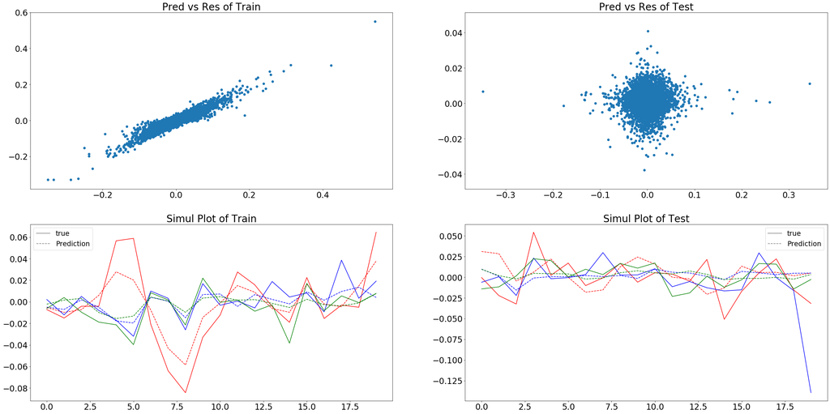

```python
directional_goodness(model_cnn_2inputs, x_test, y_test)
compare_top(model_cnn_2inputs, x_test, y_test)
plots(model_cnn_2inputs, x_test=x_test, x_train=x_train, y_test=y_test, y_train=y_train)
```

Expectations:

- CNN with additional information of industry affiliation can detect known patterns of stocks in the same category
- This leads to better predictions

Results:

- Didn´t help considerably to enhance prediction power

Conclusion:

- Patterns in stocks seem to be to variable to be efficiently detected and don´t contribute to effective prediction power in our calculation regime

### Fully Connected Neural Network

```python
def fully(x_train,y_train,x_test,y_test,inp_shape):
    verbose, epochs, batch_size = 0, 40, 50
    """
    verbose: 0-kein output, 1-ladebalken, 2-epochenzahlen printen
    batch_size: Nicht definieren (https://stackoverflow.com/questions/44747343/keras-input-explanation-input-shape-units-batch-size-dim-etc)
    epochs: Anzahl Iterationen durch das Trainingsset
    """

    N = inp_shape[1]
    #init
    model = models.Sequential()
    model.add(layers.Dense(100, activation='tanh'))
    model.add(layers.Dense(100, activation='relu'))
    model.add(layers.Dropout(.5))
    model.add(layers.Dense(100, activation='tanh'))
    model.add(layers.Flatten())
    model.add(layers.Dense(100, activation='relu'))
    model.add(layers.Dense(N, activation='linear'))

    model.compile(loss='mean_squared_error', optimizer='adam', metrics=['mse', 'mae'])
    #mean_squared_error (mse) and mean_absolute_error (mae)

    #fit network
    model.fit(x_train,y_train, epochs=epochs, #batch_size=batch_size,
              verbose=verbose)
    #evaluate model

    #Print error values for classification of goodness
    mse,mse2,mae = model.evaluate(x_test,y_test, batch_size=batch_size, verbose=verbose)
    print(mse)
    print(mse2)
    print(mae)
    return model
```

```python
def main_fully(input_df, dur, limit, variant):
    """
    input_df    die Input Matrix (duh)
    dur         Zeitfenster
    limit       Grenze für Train Test Split
    variant     prediction of next day, next month average, volatility
    """

    N = input_df.shape[1]
    D = input_df.shape[0]
    train = input_df.iloc[:limit,:]
    test = input_df.iloc[limit-dur:,:]
    print("now")
    x_train,y_train = get_data_subsets(train, dur, variant, onehot=0)
    x_test,y_test = get_data_subsets(test, dur, variant, onehot=0)
    inp_shape = (x_train.shape[1],N)

    """für Dimensions-tests"""
    print('x-train shape: ' + str(x_train.shape))
    print('y-train shape: ' + str(y_train.shape))
    print('x-test shape: ' + str(x_test.shape))
    print('y-test shape: ' + str(y_test.shape))
    print('test shape: ' + str(test.shape))

    model = fully(x_train, y_train, x_test, y_test, inp_shape)
    return model,x_train,y_train,x_test,y_test
```

```python
model_fully,x_train,y_train,x_test,y_test = main_fully(returns, 100, 2000, variant='next_day')
print(model_fully.summary())
```

```
now
x-train shape: (1900, 100, 20)
y-train shape: (1900, 20)
x-test shape: (518, 100, 20)
y-test shape: (518, 20)
test shape: (618, 20)
0.0003353271016025822
0.0003353270294610411
0.01267910748720169
Model: "sequential_4"
_________________________________________________________________
Layer (type)                 Output Shape              Param #
=================================================================
dense_10 (Dense)             (None, 100, 100)          2100
_________________________________________________________________
dense_11 (Dense)             (None, 100, 100)          10100
_________________________________________________________________
dropout_5 (Dropout)          (None, 100, 100)          0
_________________________________________________________________
dense_12 (Dense)             (None, 100, 100)          10100
_________________________________________________________________
flatten_6 (Flatten)          (None, 10000)             0
_________________________________________________________________
dense_13 (Dense)             (None, 100)               1000100
_________________________________________________________________
dense_14 (Dense)             (None, 20)                2020
=================================================================
Total params: 1,024,420
Trainable params: 1,024,420
Non-trainable params: 0
_________________________________________________________________
None
```

```
percentage of correctly predicted directions of returns: 0.5028957528957528
Difference between mean return and return of calculated top 5: 0.0008850111656919256
(518, 20)
```

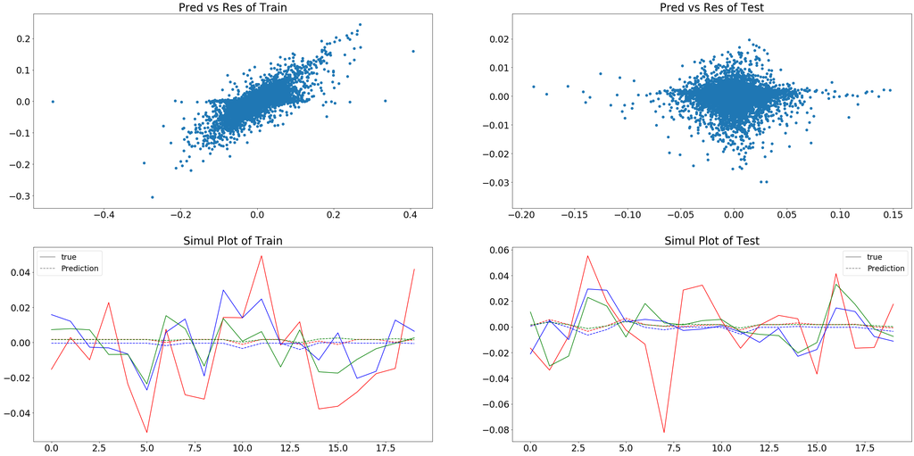

```python
directional_goodness(model_fully, x_test, y_test)
compare_top(model_fully, x_test, y_test)
plots(model_fully, x_test=x_test, x_train=x_train, y_test=y_test, y_train=y_train)
```

Expectations:

- The fully connected neural network can fit "theoretically everything"
- limited prediction power since unspecialised

Results:

- trains slowly, prediction power subpar

### Recurrent Neural Network

```python
def gru(x_train, y_train, x_test, y_test, inp_shape):
    verbose, epochs, batch_size = 0, 40, 50
    """
    verbose: 0-kein output, 1-ladebalken, 2-epochenzahlen printen
    batch_size: Nicht definieren (https://stackoverflow.com/questions/44747343/keras-input-explanation-input-shape-units-batch-size-dim-etc)
    epochs: Anzahl Iterationen durch das Trainingsset
    """

    N = inp_shape[1]
    #init
    model = models.Sequential()
    model.add(layers.GRU(42, input_shape = inp_shape, return_sequences = True))
    model.add(layers.Dropout(0.2))
    model.add(layers.GRU(42, return_sequences = False))

    #Dropout sets randomly chosen values to 0 to prevent overfitting

    #model.add(layers.MaxPooling1D(pool_size=2))
    #MaxPooling halbiert array Größe und nimmt größte Werte der Feature-Gewichtungen

    #model.add(layers.Flatten())
    #Flatten reduziert dimensionen eines arrays auf niedrigst mögliche Dimension (1xdim) (überschreibt Nullen))

    model.add(layers.Dense(100, activation='relu'))
    model.add(layers.Dense(N, activation='linear'))
    #Klassisches NN hinter Convolutional Layer geschaltet, lernt also im Feature Raum, durch Convolutional Net     vorgebenen

    model.compile(loss='mean_squared_error', optimizer='adam', metrics=['mse', 'mae'])
    #mean_squared_error (mse) and mean_absolute_error (mae)

    #fit network
    model.fit(x_train,y_train, epochs=epochs, #batch_size=batch_size,
              verbose=verbose)
    #evaluate model

    #Print error values for classification of goodness
    mse,mse2,mae = model.evaluate(x_test,y_test, batch_size=batch_size, verbose=verbose)
    print(mse)
    print(mse2)
    print(mae)
    return model
```

```python
def main_gru(input_df, dur, limit, variant):
    """
    input_df    die Input Matrix (duh)
    dur         Zeitfenster
    limit       Grenze für Train Test Split
    variant     prediction of next day, next month average, volatility
    """

    N = input_df.shape[1]
    D = input_df.shape[0]
    train = input_df.iloc[:limit,:]
    test = input_df.iloc[limit-dur:,:]
    x_train,y_train = get_data_subsets(train, dur, variant, onehot=0)
    x_test,y_test = get_data_subsets(test, dur, variant, onehot=0)
    inp_shape = (dur,N)

    x_train = x_train[:,x_train.shape[1]-dur:,:]
    x_test = x_test[:,x_test.shape[1]-dur:,:]

    """für Dimensions-tests"""
    print('x-train shape: ' + str(x_train.shape))
    print('y-train shape: ' + str(y_train.shape))
    print('x-test shape: ' + str(x_test.shape))
    print('y-test shape: ' + str(y_test.shape))
    print('test shape: ' + str(test.shape))

    model = gru(x_train, y_train, x_test, y_test, inp_shape)
    return model,x_train,y_train,x_test,y_test
```

```python
model_gru,x_train,y_train,x_test,y_test = main_gru(returns, 100, 2000, variant='next_day')
print(model_gru.summary())
```

```
x-train shape: (1900, 100, 20)
y-train shape: (1900, 20)
x-test shape: (518, 100, 20)
y-test shape: (518, 20)
test shape: (618, 20)
0.00034477751690608493
0.0003447775379754603
0.012700874358415604
Model: "sequential_5"
_________________________________________________________________
Layer (type)                 Output Shape              Param #
=================================================================
gru_1 (GRU)                  (None, 100, 42)           7938
_________________________________________________________________
dropout_6 (Dropout)          (None, 100, 42)           0
_________________________________________________________________
gru_2 (GRU)                  (None, 42)                10710
_________________________________________________________________
dense_15 (Dense)             (None, 100)               4300
_________________________________________________________________
dense_16 (Dense)             (None, 20)                2020
=================================================================
Total params: 24,968
Trainable params: 24,968
Non-trainable params: 0
_________________________________________________________________
None
```

```
percentage of correctly predicted directions of returns: 0.4920849420849421
Difference between mean return and return of calculated top 5: 0.0052093499058654905
(518, 20)
```

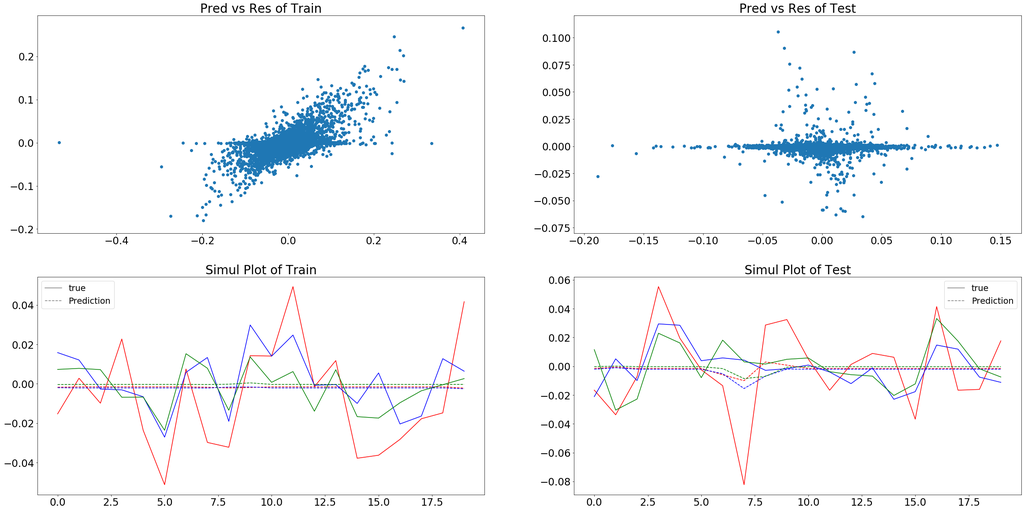

```python
directional_goodness(model_gru, x_test, y_test)
compare_top(model_gru, x_test, y_test)
plots(model_gru, x_test=x_test, x_train=x_train, y_test=y_test, y_train=y_train)
```

Expectations:

- RNN fits stock market data good, specialised on time series prediction
- GRU learns faster but less effective
- choice of hyperparameters essential

### Recurrent Neural Network with One-Hot Encoded Branch Info

```python
def gru_2inputs(xtrain,ytrain,xtest,ytest,inp_shape1,inp_shape2):
    verbose, epochs, batch_size = 0,10, 50
    """
    verbose: 0-kein output, 1-ladebalken, 2-epochenzahlen printen
    batch_size: Nicht definieren (https://stackoverflow.com/questions/44747343/keras-input-explanation-input-shape-units-batch-size-dim-etc)
    epochs: Anzahl Iterationen durch das Trainingsset
    """

    i1 = layers.Input(inp_shape1)
    i2 = layers.Input(inp_shape2)

    N = inp_shape1[1]
    #init
    model1 = layers.GRU(42, input_shape = inp_shape1, return_sequences = True)(i1)
    model1 = layers.Dropout(0.2)(model1)
    model1 = layers.GRU(42, return_sequences = False)(model1)
    #relu = 0 für value<0 sonst linear



    #model1 = layers.Flatten()(model1)
    #Flatten reduziert dimensionen eines arrays auf niedrigst mögliche Dimension (1xdim) (überschreibt Nullen))
    model1 = models.Model(inputs = i1, outputs = model1)


    ### second network:
    model2 = layers.Flatten()(i2)
    model2 = layers.Dense(100, activation="relu")(model2)
    #model2 = layers.Dropout(0.01)(model2)
    #model2 = layers.Dense(100, activation="relu")(model2)
    model2 = models.Model(inputs = i2, outputs = model2)

    combined = layers.concatenate([model1.output, model2.output])


    model = layers.Dense(100, activation='relu')(combined)
    model = layers.Dense(N, activation='linear')(model)
    model = models.Model(inputs = [model1.input, model2.input], outputs = model)
    #Klassisches NN hinter Convolutional Layer geschaltet, lernt also im Feature Raum, durch Convolutional Net          vorgebenen

    model.compile(loss='mean_squared_error', optimizer='adam', metrics=['mse', 'mae'])
    #mean_squared_error (mse) and mean_absolute_error (mae)

    #fit network
    model.fit(xtrain,ytrain, epochs=epochs, #batch_size=batch_size,
              verbose=verbose)
    #evaluate model

    #Print error values for classification of goodness
    mse,mse2,mae = model.evaluate(xtest,ytest, batch_size=batch_size, verbose=verbose)
    print(mse)
    print(mse2)
    print(mae)
    return model
```

```python
def main_gru_2inputs(input_df, dur, limit, variant):
    """
    input_df    die Input Matrix (duh)
    dur         Zeitfenster
    limit       Grenze für Train Test Split
    """

    N = input_df.shape[1]
    D = input_df.shape[0]
    train = input_df.iloc[:limit,:]
    test = input_df.iloc[limit-dur:,:]
    x_train,y_train = get_data_subsets(train, dur, variant, onehot=1)
    x_test,y_test = get_data_subsets(test, dur, variant, onehot=1)
    inp_shape1 = (dur,N)
    inp_shape2 = (x_train.shape[1]-dur,N)
    x_train = [x_train[:,inp_shape2[0]:,:],x_train[:,:inp_shape2[0],:]]
    x_test = [x_test[:,inp_shape2[0]:,:],x_test[:,:inp_shape2[0],:]]

    """für Dimensions-tests"""
    print('x-train shape: ' + str(x_train[0].shape)+ str(x_train[1].shape))
    print('y-train shape: ' + str(y_train.shape))
    print('x-test shape: ' + str(x_test[0].shape)+ str(x_test[1].shape))
    print('y-test shape: ' + str(y_test.shape))
    print('test shape: ' + str(test.shape))

    model = gru_2inputs(x_train, y_train, x_test, y_test, inp_shape1,inp_shape2)
    return model,x_train,y_train,x_test,y_test
```

```python
model_gru_2inputs,x_train,y_train,x_test,y_test = main_gru_2inputs(returns, 100, 2000, variant='next_day')
print(model_gru_2inputs.summary())
```

```
x-train shape: (1900, 100, 20)(1900, 8, 20)
y-train shape: (1900, 20)
x-test shape: (518, 100, 20)(518, 8, 20)
y-test shape: (518, 20)
test shape: (618, 20)
0.00034063294530813814
0.00034063291968777776
0.012919300235807896
Model: "model_7"
__________________________________________________________________________________________________
Layer (type)                    Output Shape         Param #     Connected to
==================================================================================================
input_5 (InputLayer)            (None, 100, 20)      0
__________________________________________________________________________________________________
gru_5 (GRU)                     (None, 100, 42)      7938        input_5[0][0]
__________________________________________________________________________________________________
input_6 (InputLayer)            (None, 8, 20)        0
__________________________________________________________________________________________________
dropout_8 (Dropout)             (None, 100, 42)      0           gru_5[0][0]
__________________________________________________________________________________________________
flatten_8 (Flatten)             (None, 160)          0           input_6[0][0]
__________________________________________________________________________________________________
gru_6 (GRU)                     (None, 42)           10710       dropout_8[0][0]
__________________________________________________________________________________________________
dense_17 (Dense)                (None, 100)          16100       flatten_8[0][0]
__________________________________________________________________________________________________
concatenate_2 (Concatenate)     (None, 142)          0           gru_6[0][0]
                                                                 dense_17[0][0]
__________________________________________________________________________________________________
dense_18 (Dense)                (None, 100)          14300       concatenate_2[0][0]
__________________________________________________________________________________________________
dense_19 (Dense)                (None, 20)           2020        dense_18[0][0]
==================================================================================================
Total params: 51,068
Trainable params: 51,068
Non-trainable params: 0
__________________________________________________________________________________________________
None
```

```
percentage of correctly predicted directions of returns: 0.4928571428571429
Difference between mean return and return of calculated top 5: 0.0018900897978871086
(518, 20)
```

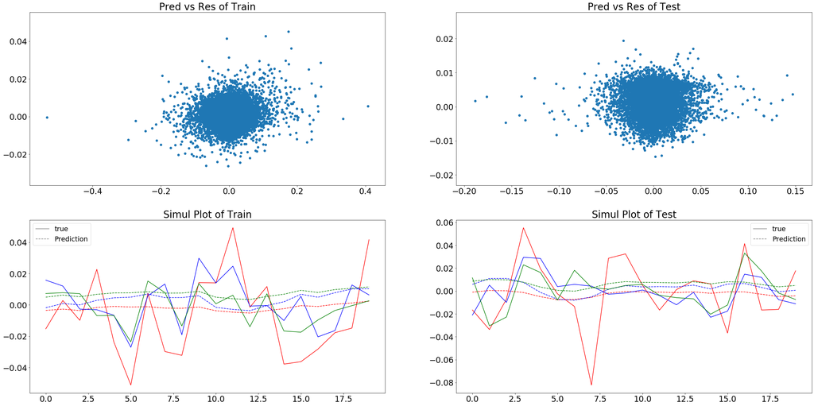

```python
directional_goodness(model_gru_2inputs, x_test, y_test)
compare_top(model_gru_2inputs, x_test, y_test)
plots(model_gru_2inputs, x_test=x_test, x_train=x_train, y_test=y_test, y_train=y_train)
```

Expectations:

- Additional Industry information adds underlying structure
- fits become better than regular RNN

### Recurrent Neural Network with Long Short-Term Memory

```python
def lstm(x_train, y_train, x_test, y_test, inp_shape):
    verbose, epochs, batch_size = 1, 10, 50
    """
    verbose: 0-kein output, 1-ladebalken, 2-epochenzahlen printen
    batch_size: Nicht definieren (https://stackoverflow.com/questions/44747343/keras-input-explanation-input-shape-units-batch-size-dim-etc)
    epochs: Anzahl Iterationen durch das Trainingsset
    """

    N = inp_shape[1]
    D = inp_shape[0]

    hidden = int(2/3*(N+D))

    #init
    model = models.Sequential()
    model.add(layers.LSTM(hidden, input_shape = inp_shape, return_sequences = True))
    model.add(layers.Dropout(0.3))
    model.add(layers.LSTM(hidden, return_sequences = False))

    #Dropout sets randomly chosen values to 0 to prevent overfitting

    #model.add(layers.MaxPooling1D(pool_size=2))
    #MaxPooling halbiert array Größe und nimmt größte Werte der Feature-Gewichtungen

    #model.add(layers.Flatten())
    #Flatten reduziert dimensionen eines arrays auf niedrigst mögliche Dimension (1xdim) (überschreibt Nullen))

    model.add(layers.Dense(100, activation='relu'))
    model.add(layers.Dense(N, activation='linear'))
    #Klassisches NN hinter Convolutional Layer geschaltet, lernt also im Feature Raum, durch Convolutional Net vorgebenen

    model.compile(loss='mean_squared_error', optimizer='adam', metrics=['mse', 'mae'])
    #mean_squared_error (mse) and mean_absolute_error (mae)
            #fit network
    model.fit(x_train,y_train, epochs=epochs, #batch_size=batch_size,
              verbose=verbose)
    #evaluate model

    #Print error values for classification of goodness
    mse,mse2,mae = model.evaluate(x_test,y_test, batch_size=batch_size, verbose=verbose)
    print(mse)
    print(mse2)
    print(mae)
    return model
```

```python
def main_lstm(input_df, dur, limit, variant):
    """
    input_df    die Input Matrix (duh)
    dur         Zeitfenster
    limit       Grenze für Train Test Split
    """

    N = input_df.shape[1]
    D = input_df.shape[0]
    train = input_df.iloc[:limit,:]
    test = input_df.iloc[limit-dur:,:]
    x_train,y_train = get_data_subsets(train, dur, variant, onehot=0)
    x_test,y_test = get_data_subsets(test, dur, variant, onehot=0)
    inp_shape = (x_train.shape[1],N)

    """für Dimensions-tests"""
    print('x-train shape: ' + str(x_train.shape))
    print('y-train shape: ' + str(y_train.shape))
    print('x-test shape: ' + str(x_test.shape))
    print('y-test shape: ' + str(y_test.shape))
    print('test shape: ' + str(test.shape))

    model = lstm(x_train, y_train, x_test, y_test, inp_shape)
    return model,x_train,y_train,x_test,y_test
```

```python
model_lstm,x_train,y_train,x_test,y_test = main_lstm(returns, 100, 2000, variant='next_day')
print(model_lstm.summary())
```

```
x-train shape: (1900, 100, 20)
y-train shape: (1900, 20)
x-test shape: (518, 100, 20)
y-test shape: (518, 20)
test shape: (618, 20)
0.0002974203630313673
0.00029742036713287234
0.011794284917414188
Model: "sequential_9"
_________________________________________________________________
Layer (type)                 Output Shape              Param #
=================================================================
lstm_1 (LSTM)                (None, 100, 80)           32320
_________________________________________________________________
dropout_10 (Dropout)         (None, 100, 80)           0
_________________________________________________________________
lstm_2 (LSTM)                (None, 80)                51520
_________________________________________________________________
dense_23 (Dense)             (None, 100)               8100
_________________________________________________________________
dense_24 (Dense)             (None, 20)                2020
=================================================================
Total params: 93,960
Trainable params: 93,960
Non-trainable params: 0
_________________________________________________________________
None
```

```
percentage of correctly predicted directions of returns: 0.5128378378378378
Difference between mean return and return of calculated top 5: 0.008068496540835746
(518, 20)
```

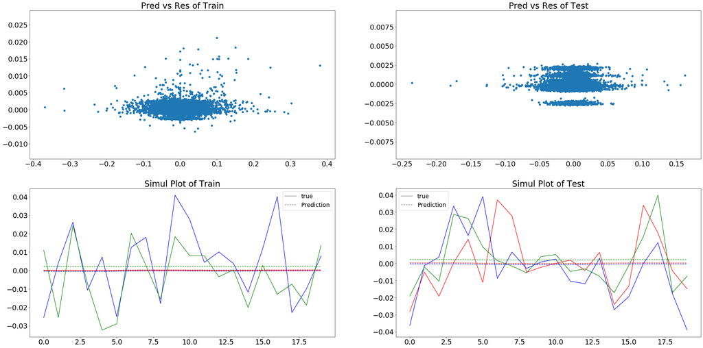

```python
directional_goodness(model_lstm, x_test, y_test)
compare_top(model_lstm, x_test, y_test)
plots(model_lstm, x_test=x_test, x_train=x_train, y_test=y_test, y_train=y_train)
```

Expectations:

- Long-Short Term Memory RNN will learn slower than regular RNN
- Should learn underlying time-series structure better than GRU RNN

```python
def lstm_2inputs(xtrain,ytrain,xtest,ytest,inp_shape1,inp_shape2):
    verbose, epochs, batch_size = 1,10, 50
    """
    verbose: 0-kein output, 1-ladebalken, 2-epochenzahlen printen
    batch_size: Nicht definieren (https://stackoverflow.com/questions/44747343/keras-input-explanation-input-shape-units-batch-size-dim-etc)
    epochs: Anzahl Iterationen durch das Trainingsset
    """

    i1 = layers.Input(inp_shape1)
    i2 = layers.Input(inp_shape2)

    N = inp_shape1[1]
    #init
    model1 = layers.GRU(42, input_shape = inp_shape1, return_sequences = True)(i1)
    model1 = layers.Dropout(0.2)(model1)
    model1 = layers.GRU(42, return_sequences = False)(model1)
    #relu = 0 für value<0 sonst linear



    #model1 = layers.Flatten()(model1)
    #Flatten reduziert dimensionen eines arrays auf niedrigst mögliche Dimension (1xdim) (überschreibt Nullen))
    model1 = models.Model(inputs = i1, outputs = model1)


    ### second network:
    model2 = layers.Flatten()(i2)
    model2 = layers.Dense(100, activation="relu")(model2)
    #model2 = layers.Dropout(0.01)(model2)
    #model2 = layers.Dense(100, activation="relu")(model2)
    model2 = models.Model(inputs = i2, outputs = model2)

    combined = layers.concatenate([model1.output, model2.output])


    model = layers.Dense(100, activation='relu')(combined)
    model = layers.Dense(N, activation='linear')(model)
    model = models.Model(inputs = [model1.input, model2.input], outputs = model)
    #Klassisches NN hinter Convolutional Layer geschaltet, lernt also im Feature Raum, durch Convolutional Net vorgebenen

    model.compile(loss='mean_squared_error', optimizer='adam', metrics=['mse', 'mae'])
    #mean_squared_error (mse) and mean_absolute_error (mae)

    #fit network
    model.fit(xtrain,ytrain, epochs=epochs, #batch_size=batch_size,
              verbose=verbose)
    #evaluate model

    #Print error values for classification of goodness
    mse,mse2,mae = model.evaluate(xtest,ytest, batch_size=batch_size, verbose=verbose)
    print(mse)
    print(mse2)
    print(mae)
    return model
```

```python
def main_lstm_2inputs(input_df, dur, limit, variant):
    """
    input_df    die Input Matrix (duh)
    dur         Zeitfenster
    limit       Grenze für Train Test Split
    """

    N = input_df.shape[1]
    D = input_df.shape[0]
    train = input_df.iloc[:limit,:]
    test = input_df.iloc[limit-dur:,:]
    x_train,y_train = get_data_subsets(train, dur, variant, onehot=1)
    x_test,y_test = get_data_subsets(test, dur, variant, onehot=1)
    inp_shape1 = (dur,N)
    inp_shape2 = (x_train.shape[1]-dur,N)
    x_train = [x_train[:,inp_shape2[0]:,:],x_train[:,:inp_shape2[0],:]]
    x_test = [x_test[:,inp_shape2[0]:,:],x_test[:,:inp_shape2[0],:]]

    """für Dimensions-tests"""
    print('x-train shape: ' + str(x_train[0].shape)+ str(x_train[1].shape))
    print('y-train shape: ' + str(y_train.shape))
    print('x-test shape: ' + str(x_test[0].shape)+ str(x_test[1].shape))
    print('y-test shape: ' + str(y_test.shape))
    print('test shape: ' + str(test.shape))

    model = lstm_2inputs(x_train, y_train, x_test, y_test, inp_shape1,inp_shape2)
    return model,x_train,y_train,x_test,y_test
```

```python
model_lstm_2inputs,x_train,y_train,x_test,y_test = main_lstm_2inputs(returns, 100, 2000, variant='next_day')
print(model_lstm_2inputs.summary())
```

```
x-train shape: (1900, 100, 20)(1900, 0, 20)
y-train shape: (1900, 20)
x-test shape: (518, 100, 20)(518, 0, 20)
y-test shape: (518, 20)
test shape: (618, 20)
```

[output not shown]

```python
directional_goodness(model_lstm_2inputs, x_test, y_test)
compare_top(model_lstm_2inputs, x_test, y_test)
plots(model_lstm_2inputs, x_test=x_test, x_train=x_train, y_test=y_test, y_train=y_train)
```

[output not shown]

[output not shown]

## Discussion and Outlook

- Neural Networks don´t really do a good job on predicting stock markets
- Patterns are too variable to be recognised as patterns by machines
- time series prediction works ok
- Input Data Transformations can be optimized, so that maybe structure is recognizable
  - smoothing, space transformation, clustering, etc
- Neural Networks can be optimized
  - hyperparameters are of the essence with most NNs
  - input shape (time window, stock number)
  - number of different kinds of neurons, layers, etc.
  - activation functions
- More computational power could help
  - sometimes NNs have a "breakthrough" in learning curve after what seems like convergence
- ..